# Sphere Tangent to a Conducting Plane

**AUTHOR**  
Rodrigo Kang

## Computational Setup

The transformed boundary-value problem is invariant under rotations about the $y'$-axis because both the geometry and the boundary conditions depend on $x'$ and $z'$ only through the radial coordinate

$$ \rho'=\sqrt{x'^2+z'^2}. $$

The three-dimensional Laplace equation can therefore be reduced to the axisymmetric form

$$ \frac{\partial^2\tilde{\phi}}{\partial \rho'^2} + \frac{1}{\rho'} \frac{\partial\tilde{\phi}}{\partial \rho'} + \frac{\partial^2\tilde{\phi}}{\partial y'^2} = 0. $$

The numerical problem is solved on a finite rectangular domain

$$ 0\leq \rho'\leq \rho'_{\max}, \qquad 0\leq y'\leq 1, $$

which approximates the infinite transformed slab. The potential is normalized by setting $V=1$.

At the lower boundary, the transformed potential is

$$ \tilde{\phi}(\rho',0)=\frac{1}{\rho'}. $$

This condition is singular at $\rho'=0$. In the numerical implementation, the singular point is regularized using the radial grid spacing, so that the boundary value remains finite while preserving the expected behaviour away from the axis.

```python
from pathlib import Path
from time import perf_counter

import matplotlib.pyplot as plt
import numpy as np
from scipy import sparse
from scipy.sparse.linalg import spsolve


# Output directories
output_dir = Path("output-sphere-conducting-plane")
figures_dir = output_dir / "figures"

figures_dir.mkdir(parents=True, exist_ok=True)


# Physical parameter
applied_potential = 1.0


# Computational domain
rho_max = 8.0
y_max = 1.0


# Grid resolution
n_rho = 241
n_y = 81


# Numerical grids
rho = np.linspace(0.0, rho_max, n_rho)
y = np.linspace(0.0, y_max, n_y)

delta_rho = rho[1] - rho[0]
delta_y = y[1] - y[0]


print(f"Radial grid spacing: {delta_rho:.5f}")
print(f"Vertical grid spacing: {delta_y:.5f}")
print(f"Number of grid points: {n_rho * n_y:,}")
```

```
Radial grid spacing: 0.03333
Vertical grid spacing: 0.01250
Number of grid points: 19,521
```

## Boundary Conditions

The transformed problem is completed by specifying the potential along the boundaries of the truncated computational domain.

At the upper plane, corresponding to the image of the conducting sphere,

$$ \tilde{\phi}(\rho',1)=0. $$

At the lower plane,

$$ \tilde{\phi}(\rho',0)=\frac{V}{\rho'}. $$

Because this expression diverges at $\rho'=0$, the value at the first radial node is approximated using $\rho'=\Delta \rho'$. This avoids division by zero while retaining the singular behaviour of the transformed boundary condition near the axis.

Axisymmetry requires the radial derivative to vanish at $\rho'=0$:

$$ \frac{\partial \tilde{\phi}}{\partial \rho'}(0,y')=0. $$

At the artificial outer boundary $\rho'=\rho'_{\max}$, the transformed potential is assumed to be sufficiently small, and the Dirichlet condition

$$ \tilde{\phi}(\rho'_{\max},y')=0 $$

is imposed. The value of $\rho'_{\max}$ should therefore be chosen large enough to minimise truncation effects.

```python
def build_boundary_values(
    rho,
    y,
    applied_potential,
    delta_rho,
):
    """
    Construct the Dirichlet boundary values for the transformed domain

    Inputs:
    -------
    rho : numpy.ndarray
        Radial grid coordinates

    y : numpy.ndarray
        Vertical grid coordinates

    applied_potential : float
        Constant potential applied to the original conducting plane

    delta_rho : float
        Radial grid spacing used to regularize the singular lower boundary

    Outputs:
    --------
    boundary_values : numpy.ndarray
        Array containing the prescribed boundary values

    Author:
    -------
    Rodrigo Kang

    """

    n_y = len(y)
    n_rho = len(rho)

    boundary_values = np.zeros((n_y, n_rho), dtype=float)

    regularized_rho = rho.copy()
    regularized_rho[0] = delta_rho

    boundary_values[0, :] = (
        applied_potential / regularized_rho
    )

    boundary_values[-1, :] = 0.0
    boundary_values[:, -1] = 0.0

    return boundary_values


boundary_values = build_boundary_values(
    rho=rho,
    y=y,
    applied_potential=applied_potential,
    delta_rho=delta_rho,
)

boundary_values.shape
```

```
(81, 241)
```

## Finite Difference Discretization

The axisymmetric Laplace equation is discretized on a uniform grid in the transformed coordinates $(\rho',y')$.

For radial nodes satisfying $\rho'_i>0$, the differential equation

$$ \frac{\partial^2\tilde{\phi}}{\partial \rho'^2} + \frac{1}{\rho'} \frac{\partial\tilde{\phi}}{\partial \rho'} + \frac{\partial^2\tilde{\phi}}{\partial y'^2} = 0 $$

is approximated using centred finite differences:

$$ \frac{ \tilde{\phi}_{j,i+1} - 2\tilde{\phi}_{j,i} + \tilde{\phi}_{j,i-1} }{ \Delta \rho'^2 } + \frac{1}{\rho'_i} \frac{ \tilde{\phi}_{j,i+1} - \tilde{\phi}_{j,i-1} }{ 2\Delta \rho' } + \frac{ \tilde{\phi}_{j+1,i} - 2\tilde{\phi}_{j,i} + \tilde{\phi}_{j-1,i} }{ \Delta y'^2 } = 0. $$

At the symmetry axis $\rho'=0$, the term containing $1/\rho'$ cannot be evaluated directly. Using the symmetry condition

$$ \frac{\partial\tilde{\phi}}{\partial \rho'}(0,y')=0, $$

the radial part of the Laplacian reduces to

$$ \left. \left( \frac{\partial^2\tilde{\phi}}{\partial \rho'^2} + \frac{1}{\rho'} \frac{\partial\tilde{\phi}}{\partial \rho'} \right) \right|_{\rho'=0} = 2 \left. \frac{\partial^2\tilde{\phi}}{\partial \rho'^2} \right|_{\rho'=0}. $$

The corresponding finite difference approximation is

$$ \frac{ 4\left( \tilde{\phi}_{j,1} - \tilde{\phi}_{j,0} \right) }{ \Delta \rho'^2 } + \frac{ \tilde{\phi}_{j+1,0} - 2\tilde{\phi}_{j,0} + \tilde{\phi}_{j-1,0} }{ \Delta y'^2 } = 0. $$

The resulting equations form a sparse linear system

$$ \mathbf{A}\boldsymbol{\phi}=\mathbf{b}, $$

where $\boldsymbol{\phi}$ contains the unknown potential values at the interior grid points and along the symmetry axis.

```python
def build_finite_difference_system(
    rho,
    y,
    delta_rho,
    delta_y,
    boundary_values,
):
    """
    Construct the sparse finite difference system for the transformed problem

    Inputs:
    -------
    rho : numpy.ndarray
        Radial grid coordinates

    y : numpy.ndarray
        Vertical grid coordinates

    delta_rho : float
        Uniform radial grid spacing

    delta_y : float
        Uniform vertical grid spacing

    boundary_values : numpy.ndarray
        Array containing the prescribed Dirichlet boundary values

    Outputs:
    --------
    coefficient_matrix : scipy.sparse.csr_matrix
        Sparse matrix containing the finite difference coefficients

    right_hand_side : numpy.ndarray
        Vector containing the contributions from the boundary conditions

    node_indices : numpy.ndarray
        Array mapping grid nodes to positions in the linear system

    Author:
    -------
    Rodrigo Kang

    """

    n_y = len(y)
    n_rho = len(rho)

    node_indices = -np.ones((n_y, n_rho), dtype=int)

    equation_index = 0

    for j in range(1, n_y - 1):
        for i in range(0, n_rho - 1):
            node_indices[j, i] = equation_index
            equation_index += 1

    n_unknowns = equation_index

    coefficient_matrix = sparse.lil_matrix(
        (n_unknowns, n_unknowns),
        dtype=float,
    )

    right_hand_side = np.zeros(n_unknowns, dtype=float)

    radial_factor = 1.0 / delta_rho**2
    vertical_factor = 1.0 / delta_y**2

    for j in range(1, n_y - 1):
        for i in range(0, n_rho - 1):
            row = node_indices[j, i]

            if i == 0:
                coefficient_matrix[row, row] = (
                    -4.0 * radial_factor
                    - 2.0 * vertical_factor
                )

                right_node = node_indices[j, i + 1]

                coefficient_matrix[row, right_node] = (
                    4.0 * radial_factor
                )

            else:
                radial_correction = 1.0 / (
                    2.0 * rho[i] * delta_rho
                )

                coefficient_matrix[row, row] = (
                    -2.0 * radial_factor
                    - 2.0 * vertical_factor
                )

                left_coefficient = (
                    radial_factor
                    - radial_correction
                )

                right_coefficient = (
                    radial_factor
                    + radial_correction
                )

                left_node = node_indices[j, i - 1]

                coefficient_matrix[row, left_node] = (
                    left_coefficient
                )

                if i + 1 == n_rho - 1:
                    right_hand_side[row] -= (
                        right_coefficient
                        * boundary_values[j, i + 1]
                    )
                else:
                    right_node = node_indices[j, i + 1]

                    coefficient_matrix[row, right_node] = (
                        right_coefficient
                    )

            lower_coefficient = vertical_factor
            upper_coefficient = vertical_factor

            if j - 1 == 0:
                right_hand_side[row] -= (
                    lower_coefficient
                    * boundary_values[j - 1, i]
                )
            else:
                lower_node = node_indices[j - 1, i]

                coefficient_matrix[row, lower_node] = (
                    lower_coefficient
                )

            if j + 1 == n_y - 1:
                right_hand_side[row] -= (
                    upper_coefficient
                    * boundary_values[j + 1, i]
                )
            else:
                upper_node = node_indices[j + 1, i]

                coefficient_matrix[row, upper_node] = (
                    upper_coefficient
                )

    coefficient_matrix = coefficient_matrix.tocsr()

    return (
        coefficient_matrix,
        right_hand_side,
        node_indices,
    )


(
    coefficient_matrix,
    right_hand_side,
    node_indices,
) = build_finite_difference_system(
    rho=rho,
    y=y,
    delta_rho=delta_rho,
    delta_y=delta_y,
    boundary_values=boundary_values,
)


print(
    f"Linear system size: "
    f"{coefficient_matrix.shape[0]:,} "
    f"x {coefficient_matrix.shape[1]:,}"
)

print(
    f"Number of non-zero coefficients: "
    f"{coefficient_matrix.nnz:,}"
)
```

```
Linear system size: 18,960 x 18,960
Number of non-zero coefficients: 94,162
```

## Numerical Solution

The sparse linear system is solved using a direct sparse solver. The resulting vector is then mapped back onto the two-dimensional grid in $(\rho',y')$.

The prescribed boundary values are retained at $y'=0$, $y'=1$, and $\rho'=\rho'_{\max}$, while the values at the remaining nodes are obtained from the finite difference solution.

```python
def solve_transformed_potential(
    coefficient_matrix,
    right_hand_side,
    node_indices,
    boundary_values,
):
    """
    Solve the finite difference system and reconstruct the potential grid

    Inputs:
    -------
    coefficient_matrix : scipy.sparse.csr_matrix
        Sparse finite difference coefficient matrix

    right_hand_side : numpy.ndarray
        Right-hand-side vector containing boundary contributions

    node_indices : numpy.ndarray
        Array mapping grid nodes to positions in the linear system

    boundary_values : numpy.ndarray
        Array containing the prescribed boundary values

    Outputs:
    --------
    transformed_potential : numpy.ndarray
        Numerical potential evaluated on the transformed grid

    Author:
    -------
    Rodrigo Kang

    """

    solution_vector = spsolve(
        coefficient_matrix,
        right_hand_side,
    )

    transformed_potential = boundary_values.copy()

    n_y, n_rho = node_indices.shape

    for j in range(1, n_y - 1):
        for i in range(0, n_rho - 1):
            solution_index = node_indices[j, i]

            transformed_potential[j, i] = (
                solution_vector[solution_index]
            )

    return transformed_potential


transformed_potential = solve_transformed_potential(
    coefficient_matrix=coefficient_matrix,
    right_hand_side=right_hand_side,
    node_indices=node_indices,
    boundary_values=boundary_values,
)


print(
    f"Minimum transformed potential: "
    f"{transformed_potential.min():.6f}"
)

print(
    f"Maximum transformed potential: "
    f"{transformed_potential.max():.6f}"
)
```

```
Minimum transformed potential: 0.000000
Maximum transformed potential: 30.000000
```

## Potential in the Transformed Domain

The numerical solution can be visualized as a contour map over the truncated transformed domain. Because the lower boundary condition behaves as $1/\rho'$, the largest potential values occur near the axis and close to the plane $y'=0$.

To make the spatial variation away from the regularized singularity easier to interpret, the colour scale is limited to a representative upper value. This affects only the visualization and does not modify the numerical solution.

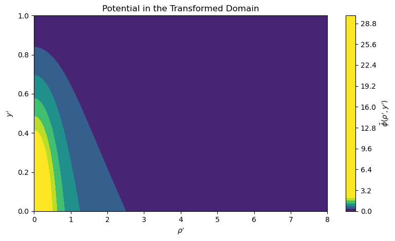

```
Figure saved to: output-sphere-conducting-plane\figures\transformed-potential.png
```

```python
def plot_transformed_potential(
    rho,
    y,
    transformed_potential,
    figures_dir,
):
    """
    Plot and save the potential in the transformed domain

    Inputs:
    -------
    rho : numpy.ndarray
        Radial grid coordinates

    y : numpy.ndarray
        Vertical grid coordinates

    transformed_potential : numpy.ndarray
        Numerical potential evaluated on the transformed grid

    figures_dir : pathlib.Path
        Directory where the figure is saved

    Outputs:
    --------
    figure_path : pathlib.Path
        Path of the saved PNG figure

    Author:
    -------
    Rodrigo Kang

    """

    rho_grid, y_grid = np.meshgrid(
        rho,
        y,
    )

    display_limit = np.percentile(
        transformed_potential,
        98.0,
    )

    figure, axis = plt.subplots(
        figsize=(8, 4.8),
    )

    contour = axis.contourf(
        rho_grid,
        y_grid,
        transformed_potential,
        levels=80,
        vmin=0.0,
        vmax=display_limit,
    )

    colorbar = figure.colorbar(
        contour,
        ax=axis,
    )

    colorbar.set_label(
        r"$\tilde{\phi}(\rho',y')$"
    )

    axis.set_xlabel(
        r"$\rho'$"
    )

    axis.set_ylabel(
        r"$y'$"
    )

    axis.set_title(
        "Potential in the Transformed Domain"
    )

    figure.tight_layout()

    figure_path = (
        figures_dir
        / "transformed-potential.png"
    )

    figure.savefig(
        figure_path,
        dpi=300,
        bbox_inches="tight",
    )

    plt.show()

    return figure_path


transformed_figure_path = plot_transformed_potential(
    rho=rho,
    y=y,
    transformed_potential=transformed_potential,
    figures_dir=figures_dir,
)


print(
    f"Figure saved to: "
    f"{transformed_figure_path}"
)
```

## Inverse Transformation

Once the transformed potential has been computed, the inverse inversion is applied to recover the solution in the original geometry.

In cylindrical coordinates, the transformed radial distance from the origin is

$$ r'=\sqrt{\rho'^2+y'^2}. $$

Because inversion is involutive, the original coordinates are obtained from

$$ \rho=\frac{\rho'}{r'^2}, \qquad y=\frac{y'}{r'^2}. $$

The Kelvin transformation relates the original and transformed potentials through

$$ \tilde{\phi}=\frac{\phi}{r'}, $$

so that

$$ \phi=r'\tilde{\phi}. $$

Points close to $r'=0$ are mapped to locations arbitrarily far from the origin. The origin of the transformed domain is therefore excluded when applying the inverse transformation. This point corresponds to spatial infinity in the original geometry.

```python
def apply_inverse_transformation(
    rho,
    y,
    transformed_potential,
):
    """
    Map the transformed grid and potential back to the original domain

    Inputs:
    -------
    rho : numpy.ndarray
        Radial coordinates in the transformed domain

    y : numpy.ndarray
        Vertical coordinates in the transformed domain

    transformed_potential : numpy.ndarray
        Numerical potential evaluated in the transformed domain

    Outputs:
    --------
    original_rho : numpy.ndarray
        Radial coordinates mapped to the original domain

    original_y : numpy.ndarray
        Vertical coordinates mapped to the original domain

    original_potential : numpy.ndarray
        Potential recovered in the original domain

    valid_points : numpy.ndarray
        Boolean mask identifying points where the inverse mapping is finite

    Author:
    -------
    Rodrigo Kang

    """

    transformed_rho_grid, transformed_y_grid = np.meshgrid(
        rho,
        y,
    )

    transformed_radius_squared = (
        transformed_rho_grid**2
        + transformed_y_grid**2
    )

    valid_points = transformed_radius_squared > 0.0

    original_rho = np.full_like(
        transformed_rho_grid,
        np.nan,
        dtype=float,
    )

    original_y = np.full_like(
        transformed_y_grid,
        np.nan,
        dtype=float,
    )

    original_potential = np.full_like(
        transformed_potential,
        np.nan,
        dtype=float,
    )

    original_rho[valid_points] = (
        transformed_rho_grid[valid_points]
        / transformed_radius_squared[valid_points]
    )

    original_y[valid_points] = (
        transformed_y_grid[valid_points]
        / transformed_radius_squared[valid_points]
    )

    transformed_radius = np.sqrt(
        transformed_radius_squared[valid_points]
    )

    original_potential[valid_points] = (
        transformed_radius
        * transformed_potential[valid_points]
    )

    return (
        original_rho,
        original_y,
        original_potential,
        valid_points,
    )


(
    original_rho,
    original_y,
    original_potential,
    valid_points,
) = apply_inverse_transformation(
    rho=rho,
    y=y,
    transformed_potential=transformed_potential,
)


print(
    f"Number of mapped points: "
    f"{np.count_nonzero(valid_points):,}"
)
```

```
Number of mapped points: 19,520
```

## Potential in the Original Domain

The inverse transformation produces a nonuniform set of points in the original $(\rho,y)$ domain. A triangular interpolation is therefore used to visualize the recovered potential.

For presentation purposes, the plot is restricted to a finite region surrounding the sphere and the conducting plane. This restriction affects only the displayed figure; the inverse transformation itself is applied to every valid grid point.

The circular boundary shown in the meridional plane corresponds to the sphere

$$ \rho^2+\left(y-\frac{1}{2}\right)^2 = \frac{1}{4}. $$

When rotated about the $y$-axis, this curve generates the original spherical conductor.

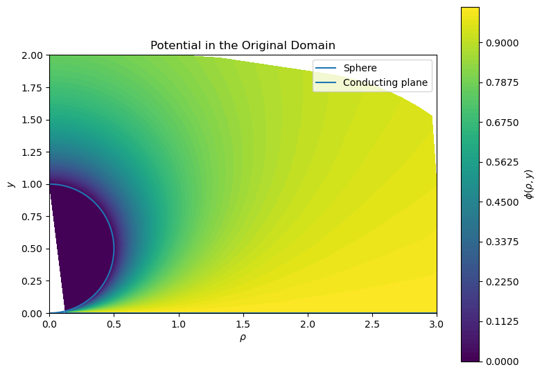

```
Figure saved to: output-sphere-conducting-plane\figures\original-potential.png
```

```python
def plot_original_potential(
    original_rho,
    original_y,
    original_potential,
    valid_points,
    figures_dir,
    rho_limit=3.0,
    y_limit=2.0,
):
    """
    Plot and save the potential recovered in the original domain

    Inputs:
    -------
    original_rho : numpy.ndarray
        Radial coordinates in the original domain

    original_y : numpy.ndarray
        Vertical coordinates in the original domain

    original_potential : numpy.ndarray
        Potential recovered in the original domain

    valid_points : numpy.ndarray
        Boolean mask identifying finite inverse-mapped points

    figures_dir : pathlib.Path
        Directory where the figure is saved

    rho_limit : float, optional
        Maximum radial coordinate displayed in the figure

    y_limit : float, optional
        Maximum vertical coordinate displayed in the figure

    Outputs:
    --------
    figure_path : pathlib.Path
        Path of the saved PNG figure

    Author:
    -------
    Rodrigo Kang

    """

    display_points = (
        valid_points
        & np.isfinite(original_potential)
        & (original_rho >= 0.0)
        & (original_rho <= rho_limit)
        & (original_y >= 0.0)
        & (original_y <= y_limit)
    )

    radial_coordinates = original_rho[display_points]
    vertical_coordinates = original_y[display_points]
    potential_values = original_potential[display_points]

    figure, axis = plt.subplots(
        figsize=(8, 5.5),
    )

    contour = axis.tricontourf(
        radial_coordinates,
        vertical_coordinates,
        potential_values,
        levels=np.linspace(
            0.0,
            applied_potential,
            81,
        ),
    )

    colorbar = figure.colorbar(
        contour,
        ax=axis,
    )

    colorbar.set_label(
        r"$\phi(\rho,y)$"
    )

    sphere_angle = np.linspace(
        0.0,
        np.pi,
        400,
    )

    sphere_rho = 0.5 * np.sin(
        sphere_angle
    )

    sphere_y = (
        0.5
        + 0.5 * np.cos(sphere_angle)
    )

    axis.plot(
        sphere_rho,
        sphere_y,
        linewidth=1.5,
        label="Sphere",
    )

    axis.axhline(
        y=0.0,
        linewidth=1.5,
        label="Conducting plane",
    )

    axis.set_xlim(
        0.0,
        rho_limit,
    )

    axis.set_ylim(
        0.0,
        y_limit,
    )

    axis.set_xlabel(
        r"$\rho$"
    )

    axis.set_ylabel(
        r"$y$"
    )

    axis.set_title(
        "Potential in the Original Domain"
    )

    axis.set_aspect(
        "equal",
        adjustable="box",
    )

    axis.legend(
        loc="upper right",
    )

    figure.tight_layout()

    figure_path = (
        figures_dir
        / "original-potential.png"
    )

    figure.savefig(
        figure_path,
        dpi=300,
        bbox_inches="tight",
    )

    plt.show()

    return figure_path


original_figure_path = plot_original_potential(
    original_rho=original_rho,
    original_y=original_y,
    original_potential=original_potential,
    valid_points=valid_points,
    figures_dir=figures_dir,
)


print(
    f"Figure saved to: "
    f"{original_figure_path}"
)
```

## Numerical Validation

The numerical solution is assessed by evaluating the discrete residual of the axisymmetric Laplace equation at the interior grid points.

For $\rho'_i>0$, the residual is computed from

$$ R_{j,i} = \frac{ \tilde{\phi}_{j,i+1} - 2\tilde{\phi}_{j,i} + \tilde{\phi}_{j,i-1} }{ \Delta \rho'^2 } + \frac{1}{\rho'_i} \frac{ \tilde{\phi}_{j,i+1} - \tilde{\phi}_{j,i-1} }{ 2\Delta \rho' } + \frac{ \tilde{\phi}_{j+1,i} - 2\tilde{\phi}_{j,i} + \tilde{\phi}_{j-1,i} }{ \Delta y'^2 }. $$

At the symmetry axis, the corresponding expression is

$$ R_{j,0} = \frac{ 4\left( \tilde{\phi}_{j,1} - \tilde{\phi}_{j,0} \right) }{ \Delta \rho'^2 } + \frac{ \tilde{\phi}_{j+1,0} - 2\tilde{\phi}_{j,0} + \tilde{\phi}_{j-1,0} }{ \Delta y'^2 }. $$

A small residual indicates that the numerical solution satisfies the discretized Laplace equation to within the accuracy of the linear solver and floating-point arithmetic.

```python
def compute_discrete_residual(
    rho,
    transformed_potential,
    delta_rho,
    delta_y,
):
    """
    Compute the discrete residual of the axisymmetric Laplace equation

    Inputs:
    -------
    rho : numpy.ndarray
        Radial grid coordinates

    transformed_potential : numpy.ndarray
        Numerical potential evaluated on the transformed grid

    delta_rho : float
        Uniform radial grid spacing

    delta_y : float
        Uniform vertical grid spacing

    Outputs:
    --------
    residual : numpy.ndarray
        Discrete residual evaluated at the interior grid points

    Author:
    -------
    Rodrigo Kang

    """

    n_y, n_rho = transformed_potential.shape

    residual = np.full(
        (n_y, n_rho),
        np.nan,
        dtype=float,
    )

    radial_factor = 1.0 / delta_rho**2
    vertical_factor = 1.0 / delta_y**2

    for j in range(1, n_y - 1):
        residual[j, 0] = (
            4.0
            * radial_factor
            * (
                transformed_potential[j, 1]
                - transformed_potential[j, 0]
            )
            + vertical_factor
            * (
                transformed_potential[j + 1, 0]
                - 2.0 * transformed_potential[j, 0]
                + transformed_potential[j - 1, 0]
            )
        )

        for i in range(1, n_rho - 1):
            radial_second_derivative = (
                transformed_potential[j, i + 1]
                - 2.0 * transformed_potential[j, i]
                + transformed_potential[j, i - 1]
            ) * radial_factor

            radial_first_derivative = (
                transformed_potential[j, i + 1]
                - transformed_potential[j, i - 1]
            ) / (2.0 * delta_rho)

            vertical_second_derivative = (
                transformed_potential[j + 1, i]
                - 2.0 * transformed_potential[j, i]
                + transformed_potential[j - 1, i]
            ) * vertical_factor

            residual[j, i] = (
                radial_second_derivative
                + radial_first_derivative / rho[i]
                + vertical_second_derivative
            )

    return residual


residual = compute_discrete_residual(
    rho=rho,
    transformed_potential=transformed_potential,
    delta_rho=delta_rho,
    delta_y=delta_y,
)


interior_residual = residual[
    1:-1,
    :-1,
]

maximum_residual = np.nanmax(
    np.abs(interior_residual)
)

mean_residual = np.nanmean(
    np.abs(interior_residual)
)


print(
    f"Maximum absolute residual: "
    f"{maximum_residual:.6e}"
)

print(
    f"Mean absolute residual: "
    f"{mean_residual:.6e}"
)
```

```
Maximum absolute residual: 5.547918e-11
Mean absolute residual: 4.747375e-13
```

## Residual Distribution

The spatial distribution of the absolute residual is shown on a logarithmic scale. This makes it possible to identify regions where the discretization error is comparatively larger.

The residual is expected to be most sensitive near the regularized singularity at $\rho'=0$ and $y'=0$, where the lower boundary condition varies rapidly. Away from this region, the residual should remain close to the numerical precision of the sparse linear solve.

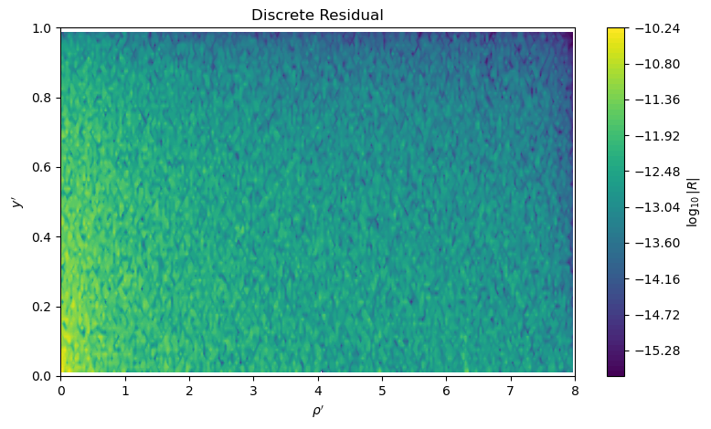

```
Figure saved to: output-sphere-conducting-plane\figures\residual-map.png
```

```python
def plot_residual_distribution(
    rho,
    y,
    residual,
    figures_dir,
):
    """
    Plot and save the absolute discrete residual in the transformed domain

    Inputs:
    -------
    rho : numpy.ndarray
        Radial grid coordinates

    y : numpy.ndarray
        Vertical grid coordinates

    residual : numpy.ndarray
        Discrete residual evaluated on the transformed grid

    figures_dir : pathlib.Path
        Directory where the figure is saved

    Outputs:
    --------
    figure_path : pathlib.Path
        Path of the saved PNG figure

    Author:
    -------
    Rodrigo Kang

    """

    rho_grid, y_grid = np.meshgrid(
        rho,
        y,
    )

    absolute_residual = np.abs(
        residual
    )

    residual_floor = np.finfo(float).eps

    logarithmic_residual = np.log10(
        np.maximum(
            absolute_residual,
            residual_floor,
        )
    )

    figure, axis = plt.subplots(
        figsize=(8, 4.8),
    )

    contour = axis.contourf(
        rho_grid,
        y_grid,
        logarithmic_residual,
        levels=80,
    )

    colorbar = figure.colorbar(
        contour,
        ax=axis,
    )

    colorbar.set_label(
        r"$\log_{10}|R|$"
    )

    axis.set_xlabel(
        r"$\rho'$"
    )

    axis.set_ylabel(
        r"$y'$"
    )

    axis.set_title(
        "Discrete Residual"
    )

    figure.tight_layout()

    figure_path = (
        figures_dir
        / "residual-map.png"
    )

    figure.savefig(
        figure_path,
        dpi=300,
        bbox_inches="tight",
    )

    plt.show()

    return figure_path


residual_figure_path = plot_residual_distribution(
    rho=rho,
    y=y,
    residual=residual,
    figures_dir=figures_dir,
)


print(
    f"Figure saved to: "
    f"{residual_figure_path}"
)
```

## Grid Convergence

A grid convergence study is performed to evaluate how the numerical solution changes as the spatial discretization is refined.

Because no closed-form solution is available for the complete transformed problem, the solutions obtained on successive grids are compared at a set of common evaluation points. The potential from each refined grid is interpolated onto the coarser reference grid, and the relative difference is measured using the discrete $L^2$ norm,

$$ \varepsilon_h = \frac{ \left\| \tilde{\phi}_{h} - \tilde{\phi}_{h/2} \right\|_2 }{ \left\| \tilde{\phi}_{h/2} \right\|_2 }. $$

A decreasing value of $\varepsilon_h$ indicates that the numerical solution is approaching a grid-independent result.

```python
from scipy.interpolate import RegularGridInterpolator


def solve_on_grid(
    rho_max,
    y_max,
    n_rho,
    n_y,
    applied_potential,
):
    """
    Solve the transformed boundary-value problem on a specified grid

    Inputs:
    -------
    rho_max : float
        Maximum radial coordinate of the truncated domain

    y_max : float
        Maximum vertical coordinate of the transformed domain

    n_rho : int
        Number of radial grid points

    n_y : int
        Number of vertical grid points

    applied_potential : float
        Constant potential applied to the original conducting plane

    Outputs:
    --------
    rho : numpy.ndarray
        Radial grid coordinates

    y : numpy.ndarray
        Vertical grid coordinates

    transformed_potential : numpy.ndarray
        Numerical potential evaluated on the transformed grid

    Author:
    -------
    Rodrigo Kang

    """

    rho = np.linspace(
        0.0,
        rho_max,
        n_rho,
    )

    y = np.linspace(
        0.0,
        y_max,
        n_y,
    )

    delta_rho = rho[1] - rho[0]
    delta_y = y[1] - y[0]

    boundary_values = build_boundary_values(
        rho=rho,
        y=y,
        applied_potential=applied_potential,
        delta_rho=delta_rho,
    )

    (
        coefficient_matrix,
        right_hand_side,
        node_indices,
    ) = build_finite_difference_system(
        rho=rho,
        y=y,
        delta_rho=delta_rho,
        delta_y=delta_y,
        boundary_values=boundary_values,
    )

    transformed_potential = solve_transformed_potential(
        coefficient_matrix=coefficient_matrix,
        right_hand_side=right_hand_side,
        node_indices=node_indices,
        boundary_values=boundary_values,
    )

    return (
        rho,
        y,
        transformed_potential,
    )
```

### Relative Grid Differences

Only points satisfying

$$ \rho'\geq 0.25, \qquad y'\geq 0.05 $$

are included in the convergence measure.

```python
def compute_grid_differences(
    coarse_rho,
    coarse_y,
    coarse_potential,
    fine_rho,
    fine_y,
    fine_potential,
    rho_min=0.25,
    y_min=0.05,
):
    """
    Compute differences between two numerical grid solutions

    Inputs:
    -------
    coarse_rho : numpy.ndarray
        Radial coordinates of the coarse grid

    coarse_y : numpy.ndarray
        Vertical coordinates of the coarse grid

    coarse_potential : numpy.ndarray
        Potential evaluated on the coarse grid

    fine_rho : numpy.ndarray
        Radial coordinates of the fine grid

    fine_y : numpy.ndarray
        Vertical coordinates of the fine grid

    fine_potential : numpy.ndarray
        Potential evaluated on the fine grid

    rho_min : float, optional
        Minimum radial coordinate included in the comparison

    y_min : float, optional
        Minimum vertical coordinate included in the comparison

    Outputs:
    --------
    relative_l2_difference : float
        Relative discrete L2 difference between the two solutions

    maximum_absolute_difference : float
        Maximum absolute difference between the two solutions

    Author:
    -------
    Rodrigo Kang

    """

    interpolator = RegularGridInterpolator(
        (fine_y, fine_rho),
        fine_potential,
        bounds_error=False,
        fill_value=np.nan,
    )

    coarse_rho_grid, coarse_y_grid = np.meshgrid(
        coarse_rho,
        coarse_y,
    )

    evaluation_points = np.column_stack(
        (
            coarse_y_grid.ravel(),
            coarse_rho_grid.ravel(),
        )
    )

    interpolated_fine_potential = interpolator(
        evaluation_points
    ).reshape(coarse_potential.shape)

    comparison_mask = (
        (coarse_rho_grid >= rho_min)
        & (coarse_y_grid >= y_min)
        & np.isfinite(interpolated_fine_potential)
        & np.isfinite(coarse_potential)
    )

    difference = (
        coarse_potential[comparison_mask]
        - interpolated_fine_potential[comparison_mask]
    )

    reference_values = interpolated_fine_potential[
        comparison_mask
    ]

    relative_l2_difference = (
        np.linalg.norm(difference)
        / np.linalg.norm(reference_values)
    )

    maximum_absolute_difference = np.max(
        np.abs(difference)
    )

    return (
        relative_l2_difference,
        maximum_absolute_difference,
    )
```

```python
grid_sizes = [
    (41, 21),
    (81, 41),
    (161, 81),
    (321, 161),
]

grid_solutions = []
grid_solve_times = []

for current_n_rho, current_n_y in grid_sizes:
    solve_start = perf_counter()

    (
        current_rho,
        current_y,
        current_potential,
    ) = solve_on_grid(
        rho_max=rho_max,
        y_max=y_max,
        n_rho=current_n_rho,
        n_y=current_n_y,
        applied_potential=applied_potential,
    )

    solve_seconds = perf_counter() - solve_start

    grid_solutions.append(
        (
            current_rho,
            current_y,
            current_potential,
        )
    )

    grid_solve_times.append(solve_seconds)

    print(
        f"Solved grid: {current_n_rho} x {current_n_y} "
        f"in {solve_seconds:.3f} s"
    )


grid_differences = []
grid_maximum_differences = []

for grid_index in range(len(grid_solutions) - 1):
    (
        coarse_rho,
        coarse_y,
        coarse_potential,
    ) = grid_solutions[grid_index]

    (
        fine_rho,
        fine_y,
        fine_potential,
    ) = grid_solutions[grid_index + 1]

    (
        relative_l2_difference,
        maximum_absolute_difference,
    ) = compute_grid_differences(
        coarse_rho=coarse_rho,
        coarse_y=coarse_y,
        coarse_potential=coarse_potential,
        fine_rho=fine_rho,
        fine_y=fine_y,
        fine_potential=fine_potential,
    )

    grid_differences.append(relative_l2_difference)
    grid_maximum_differences.append(
        maximum_absolute_difference
    )

    print(
        f"Grid {grid_sizes[grid_index]} -> "
        f"{grid_sizes[grid_index + 1]}: "
        f"relative L2 = {relative_l2_difference:.6e}, "
        f"maximum absolute = {maximum_absolute_difference:.6e}"
    )
```

```
Solved grid: 41 x 21 in 0.010 s
Solved grid: 81 x 41 in 0.037 s
Solved grid: 161 x 81 in 0.149 s
Solved grid: 321 x 161 in 0.655 s
Grid (41, 21) -> (81, 41): relative L2 = 3.115535e-02, maximum absolute = 9.956764e-02
Grid (81, 41) -> (161, 81): relative L2 = 1.892064e-02, maximum absolute = 8.863640e-02
Grid (161, 81) -> (321, 161): relative L2 = 1.028523e-02, maximum absolute = 6.219708e-02
```

## Grid Convergence Plot

The relative differences between successive grid solutions are plotted against the characteristic radial grid spacing $\Delta \rho'$. A downward trend indicates that the potential field becomes progressively less sensitive to further grid refinement.

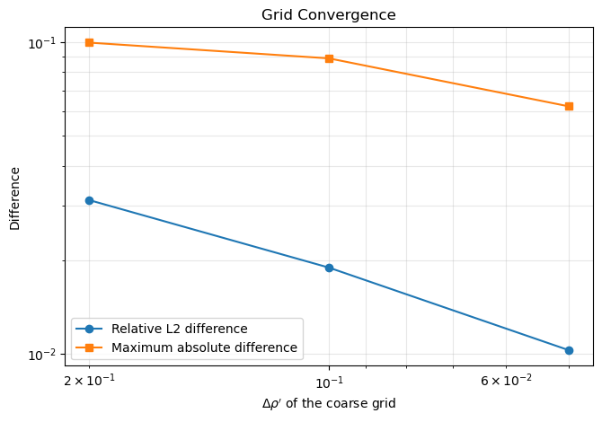

```
Figure saved to: output-sphere-conducting-plane\figures\grid-convergence.png
```

```python
def plot_grid_convergence(
    grid_sizes,
    grid_differences,
    grid_maximum_differences,
    rho_max,
    figures_dir,
):
    """
    Plot and save differences between successive grid solutions

    Inputs:
    -------
    grid_sizes : list of tuple
        Grid dimensions used in the convergence study

    grid_differences : list of float
        Relative L2 differences between successive solutions

    grid_maximum_differences : list of float
        Maximum absolute differences between successive solutions

    rho_max : float
        Maximum radial coordinate of the computational domain

    figures_dir : pathlib.Path
        Directory where the figure is saved

    Outputs:
    --------
    figure_path : pathlib.Path
        Path of the saved PNG figure

    Author:
    -------
    Rodrigo Kang

    """

    radial_spacings = np.array(
        [
            rho_max / (n_rho - 1)
            for n_rho, _ in grid_sizes[:-1]
        ]
    )

    figure, axis = plt.subplots(
        figsize=(6.8, 4.8),
    )

    axis.loglog(
        radial_spacings,
        np.asarray(grid_differences),
        marker="o",
        label="Relative L2 difference",
    )

    axis.loglog(
        radial_spacings,
        np.asarray(grid_maximum_differences),
        marker="s",
        label="Maximum absolute difference",
    )

    axis.set_xlabel(r"$\Delta \rho'$ of the coarse grid")
    axis.set_ylabel("Difference")
    axis.set_title("Grid Convergence")
    axis.grid(True, which="both", alpha=0.3)
    axis.legend()

    axis.invert_xaxis()

    figure.tight_layout()

    figure_path = figures_dir / "grid-convergence.png"

    figure.savefig(
        figure_path,
        dpi=300,
        bbox_inches="tight",
    )

    plt.show()

    return figure_path


grid_convergence_figure_path = plot_grid_convergence(
    grid_sizes=grid_sizes,
    grid_differences=grid_differences,
    grid_maximum_differences=grid_maximum_differences,
    rho_max=rho_max,
    figures_dir=figures_dir,
)

print(f"Figure saved to: {grid_convergence_figure_path}")
```

## Boundary Condition Verification

The numerical solution should reproduce the prescribed Dirichlet conditions at the upper, lower, and outer boundaries of the transformed domain.

At the upper plane,

$$ \tilde{\phi}(\rho',1)=0, $$

while at the lower plane,

$$ \tilde{\phi}(\rho',0)=\frac{V}{\rho'}. $$

At the artificial radial boundary,

$$ \tilde{\phi}(\rho'_{\max},y')=0. $$

```python
def compute_boundary_errors(
    rho,
    transformed_potential,
    applied_potential,
):
    """
    Compute numerical errors along the regular Dirichlet boundaries

    Inputs:
    -------
    rho : numpy.ndarray
        Radial grid coordinates

    transformed_potential : numpy.ndarray
        Numerical potential evaluated on the transformed grid

    applied_potential : float
        Constant potential applied to the original conducting plane

    Outputs:
    --------
    boundary_errors : dict
        Maximum absolute errors along the prescribed boundaries

    Author:
    -------
    Rodrigo Kang

    """

    expected_lower_boundary = (
        applied_potential / rho[1:-1]
    )

    lower_error = np.max(
        np.abs(
            transformed_potential[0, 1:-1]
            - expected_lower_boundary
        )
    )

    upper_error = np.max(
        np.abs(transformed_potential[-1, :])
    )

    outer_error = np.max(
        np.abs(transformed_potential[:, -1])
    )

    boundary_errors = {
        "lower_boundary": lower_error,
        "upper_boundary": upper_error,
        "outer_boundary": outer_error,
    }

    return boundary_errors


boundary_errors = compute_boundary_errors(
    rho=rho,
    transformed_potential=transformed_potential,
    applied_potential=applied_potential,
)

for boundary_name, boundary_error in boundary_errors.items():
    print(f"{boundary_name}: {boundary_error:.6e}")
```

```
lower_boundary: 0.000000e+00
upper_boundary: 0.000000e+00
outer_boundary: 0.000000e+00
```

## Potential Profiles

One-dimensional profiles provide a clearer view of how the transformed potential varies across the slab.

Vertical profiles are extracted at selected radial positions. Each profile begins at the prescribed lower-boundary value and decreases towards zero at the upper plane.

Radial profiles are also evaluated at selected values of $y'$. These curves show how the potential decays as the distance from the symmetry axis increases.

```python
def find_nearest_index(
    coordinates,
    target_value,
):
    """
    Find the index of the coordinate closest to a target value

    Inputs:
    -------
    coordinates : numpy.ndarray
        One-dimensional coordinate array

    target_value : float
        Coordinate value to be approximated

    Outputs:
    --------
    nearest_index : int
        Index of the nearest coordinate value

    Author:
    -------
    Rodrigo Kang

    """

    nearest_index = int(
        np.argmin(
            np.abs(
                coordinates - target_value
            )
        )
    )

    return nearest_index
```

### Vertical Profiles

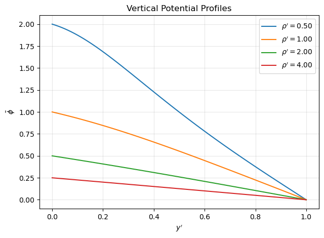

```
Figure saved to: output-sphere-conducting-plane\figures\vertical-profiles.png
```

```python
def plot_vertical_profiles(
    rho,
    y,
    transformed_potential,
    selected_rho_values,
    figures_dir,
):
    """
    Plot and save vertical potential profiles at selected radial positions

    Inputs:
    -------
    rho : numpy.ndarray
        Radial grid coordinates

    y : numpy.ndarray
        Vertical grid coordinates

    transformed_potential : numpy.ndarray
        Numerical potential evaluated on the transformed grid

    selected_rho_values : list of float
        Radial coordinates used to extract the profiles

    figures_dir : pathlib.Path
        Directory where the figure is saved

    Outputs:
    --------
    figure_path : pathlib.Path
        Path of the saved PNG figure

    Author:
    -------
    Rodrigo Kang

    """

    figure, axis = plt.subplots(
        figsize=(6.5, 4.8),
    )

    for selected_rho in selected_rho_values:
        rho_index = find_nearest_index(
            coordinates=rho,
            target_value=selected_rho,
        )

        axis.plot(
            y,
            transformed_potential[:, rho_index],
            label=(
                rf"$\rho'={rho[rho_index]:.2f}$"
            ),
        )

    axis.set_xlabel(
        r"$y'$"
    )

    axis.set_ylabel(
        r"$\tilde{\phi}$"
    )

    axis.set_title(
        "Vertical Potential Profiles"
    )

    axis.legend()

    axis.grid(
        True,
        alpha=0.3,
    )

    figure.tight_layout()

    figure_path = (
        figures_dir
        / "vertical-profiles.png"
    )

    figure.savefig(
        figure_path,
        dpi=300,
        bbox_inches="tight",
    )

    plt.show()

    return figure_path


vertical_profiles_path = plot_vertical_profiles(
    rho=rho,
    y=y,
    transformed_potential=transformed_potential,
    selected_rho_values=[
        0.5,
        1.0,
        2.0,
        4.0,
    ],
    figures_dir=figures_dir,
)


print(
    f"Figure saved to: "
    f"{vertical_profiles_path}"
)
```

### Radial Profiles

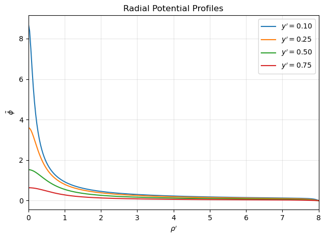

```
Figure saved to: output-sphere-conducting-plane\figures\radial-profiles.png
```

```python
def plot_radial_profiles(
    rho,
    y,
    transformed_potential,
    selected_y_values,
    figures_dir,
):
    """
    Plot and save radial potential profiles at selected vertical positions

    Inputs:
    -------
    rho : numpy.ndarray
        Radial grid coordinates

    y : numpy.ndarray
        Vertical grid coordinates

    transformed_potential : numpy.ndarray
        Numerical potential evaluated on the transformed grid

    selected_y_values : list of float
        Vertical coordinates used to extract the profiles

    figures_dir : pathlib.Path
        Directory where the figure is saved

    Outputs:
    --------
    figure_path : pathlib.Path
        Path of the saved PNG figure

    Author:
    -------
    Rodrigo Kang

    """

    figure, axis = plt.subplots(
        figsize=(6.5, 4.8),
    )

    for selected_y in selected_y_values:
        y_index = find_nearest_index(
            coordinates=y,
            target_value=selected_y,
        )

        axis.plot(
            rho,
            transformed_potential[y_index, :],
            label=(
                rf"$y'={y[y_index]:.2f}$"
            ),
        )

    axis.set_xlabel(
        r"$\rho'$"
    )

    axis.set_ylabel(
        r"$\tilde{\phi}$"
    )

    axis.set_title(
        "Radial Potential Profiles"
    )

    axis.set_xlim(
        0.0,
        rho_max,
    )

    axis.legend()

    axis.grid(
        True,
        alpha=0.3,
    )

    figure.tight_layout()

    figure_path = (
        figures_dir
        / "radial-profiles.png"
    )

    figure.savefig(
        figure_path,
        dpi=300,
        bbox_inches="tight",
    )

    plt.show()

    return figure_path


radial_profiles_path = plot_radial_profiles(
    rho=rho,
    y=y,
    transformed_potential=transformed_potential,
    selected_y_values=[
        0.1,
        0.25,
        0.5,
        0.75,
    ],
    figures_dir=figures_dir,
)


print(
    f"Figure saved to: "
    f"{radial_profiles_path}"
)
```

## Electric Field in the Original Domain

The electric field is obtained from the recovered potential through

$$ \mathbf{E} = -\nabla\phi. $$

Under axisymmetry, the field has radial and vertical components,

$$ \mathbf{E} = E_{\rho}\,\mathbf{e}_{\rho} + E_y\,\mathbf{e}_y, $$

where

$$ E_{\rho} = -\frac{\partial\phi}{\partial\rho}, \qquad E_y = -\frac{\partial\phi}{\partial y}. $$

The inverse transformation produces an irregular distribution of points in the original domain. The recovered potential is therefore interpolated onto a uniform rectangular grid before its spatial derivatives are approximated numerically.

Points lying inside the conducting sphere are excluded from the interpolation domain. The magnitude of the electric field is then calculated as

$$ \lVert\mathbf{E}\rVert = \sqrt{ E_{\rho}^2 + E_y^2 }. $$

Because the field varies rapidly near the point of tangency, extreme values are clipped only for visualization. The computed field itself is not modified.

```python
from scipy.interpolate import griddata


def interpolate_original_potential(
    original_rho,
    original_y,
    original_potential,
    valid_points,
    rho_limit,
    y_limit,
    sphere_potential=0.0,
    n_rho_plot=241,
    n_y_plot=161,
):
    """
    Interpolate the recovered potential onto a uniform original-domain grid

    Inputs:
    -------
    original_rho : numpy.ndarray
        Radial coordinates mapped to the original domain

    original_y : numpy.ndarray
        Vertical coordinates mapped to the original domain

    original_potential : numpy.ndarray
        Potential recovered in the original domain

    valid_points : numpy.ndarray
        Boolean mask identifying finite inverse-mapped points

    rho_limit : float
        Maximum radial coordinate of the interpolation grid

    y_limit : float
        Maximum vertical coordinate of the interpolation grid

    sphere_potential : float, optional
        Constant potential inside the spherical conductor

    n_rho_plot : int, optional
        Number of radial points in the uniform interpolation grid

    n_y_plot : int, optional
        Number of vertical points in the uniform interpolation grid

    Outputs:
    --------
    rho_uniform : numpy.ndarray
        Uniform radial coordinates in the original domain

    y_uniform : numpy.ndarray
        Uniform vertical coordinates in the original domain

    rho_uniform_grid : numpy.ndarray
        Two-dimensional radial coordinate grid

    y_uniform_grid : numpy.ndarray
        Two-dimensional vertical coordinate grid

    potential_uniform : numpy.ndarray
        Potential interpolated onto the uniform grid

    exterior_mask : numpy.ndarray
        Boolean mask identifying points outside the conducting sphere

    Author:
    -------
    Rodrigo Kang

    """

    source_mask = (
        valid_points
        & np.isfinite(original_potential)
        & (original_rho >= 0.0)
        & (original_rho <= rho_limit)
        & (original_y >= 0.0)
        & (original_y <= y_limit)
    )

    source_points = np.column_stack(
        (
            original_rho[source_mask],
            original_y[source_mask],
        )
    )

    source_values = original_potential[source_mask]

    rho_uniform = np.linspace(0.0, rho_limit, n_rho_plot)
    y_uniform = np.linspace(0.0, y_limit, n_y_plot)

    rho_uniform_grid, y_uniform_grid = np.meshgrid(
        rho_uniform,
        y_uniform,
    )

    potential_uniform = griddata(
        points=source_points,
        values=source_values,
        xi=(rho_uniform_grid, y_uniform_grid),
        method="linear",
    )

    missing_mask = ~np.isfinite(potential_uniform)

    if np.any(missing_mask):
        potential_uniform[missing_mask] = griddata(
            points=source_points,
            values=source_values,
            xi=(
                rho_uniform_grid[missing_mask],
                y_uniform_grid[missing_mask],
            ),
            method="nearest",
        )

    sphere_function = (
        rho_uniform_grid**2
        + (y_uniform_grid - 0.5) ** 2
        - 0.25
    )

    exterior_mask = sphere_function >= 0.0
    potential_uniform[~exterior_mask] = sphere_potential

    return (
        rho_uniform,
        y_uniform,
        rho_uniform_grid,
        y_uniform_grid,
        potential_uniform,
        exterior_mask,
    )


(
    rho_uniform,
    y_uniform,
    rho_uniform_grid,
    y_uniform_grid,
    potential_uniform,
    exterior_mask,
) = interpolate_original_potential(
    original_rho=original_rho,
    original_y=original_y,
    original_potential=original_potential,
    valid_points=valid_points,
    rho_limit=3.0,
    y_limit=2.0,
    sphere_potential=0.0,
)

print(
    f"Uniform interpolation grid: "
    f"{len(rho_uniform)} x {len(y_uniform)}"
)
```

```
Uniform interpolation grid: 241 x 161
```

## Equipotential Lines in the Original Domain

Equipotential curves complement the filled potential map by showing the geometry of constant-potential surfaces more directly. The curves should meet the conducting boundaries consistently and remain smooth away from the tangency singularity.

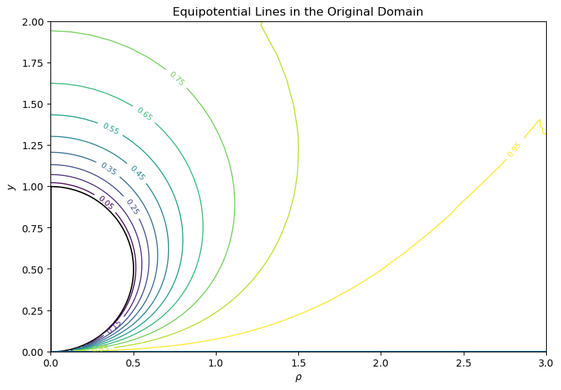

```
Figure saved to: output-sphere-conducting-plane\figures\original-equipotentials.png
```

```python
def plot_original_equipotentials(
    rho_uniform_grid,
    y_uniform_grid,
    potential_uniform,
    exterior_mask,
    figures_dir,
    applied_potential,
):
    """
    Plot and save equipotential lines in the original domain

    Inputs:
    -------
    rho_uniform_grid : numpy.ndarray
        Two-dimensional radial coordinate grid

    y_uniform_grid : numpy.ndarray
        Two-dimensional vertical coordinate grid

    potential_uniform : numpy.ndarray
        Potential interpolated onto the uniform original-domain grid

    exterior_mask : numpy.ndarray
        Boolean mask identifying points outside the spherical conductor

    figures_dir : pathlib.Path
        Directory where the figure is saved

    applied_potential : float
        Potential prescribed on the conducting plane

    Outputs:
    --------
    figure_path : pathlib.Path
        Path of the saved PNG figure

    Author:
    -------
    Rodrigo Kang

    """

    displayed_potential = np.ma.masked_where(
        ~exterior_mask,
        potential_uniform,
    )

    figure, axis = plt.subplots(figsize=(8, 5.5))

    contour = axis.contour(
        rho_uniform_grid,
        y_uniform_grid,
        displayed_potential,
        levels=np.linspace(0.05, 0.95, 10) * applied_potential,
        linewidths=1.0,
    )

    axis.clabel(contour, inline=True, fontsize=8)

    sphere_angle = np.linspace(0.0, np.pi, 400)
    sphere_rho = 0.5 * np.sin(sphere_angle)
    sphere_y = 0.5 + 0.5 * np.cos(sphere_angle)

    axis.fill_betweenx(
        sphere_y,
        0.0,
        sphere_rho,
        facecolor="white",
        edgecolor="black",
        linewidth=1.3,
    )

    axis.axhline(y=0.0, linewidth=1.5)
    axis.set_xlabel(r"$\rho$")
    axis.set_ylabel(r"$y$")
    axis.set_title("Equipotential Lines in the Original Domain")
    axis.set_xlim(rho_uniform_grid.min(), rho_uniform_grid.max())
    axis.set_ylim(y_uniform_grid.min(), y_uniform_grid.max())
    axis.set_aspect("equal", adjustable="box")

    figure.tight_layout()

    figure_path = figures_dir / "original-equipotentials.png"
    figure.savefig(figure_path, dpi=300, bbox_inches="tight")
    plt.show()

    return figure_path


original_equipotential_figure_path = plot_original_equipotentials(
    rho_uniform_grid=rho_uniform_grid,
    y_uniform_grid=y_uniform_grid,
    potential_uniform=potential_uniform,
    exterior_mask=exterior_mask,
    figures_dir=figures_dir,
    applied_potential=applied_potential,
)

print(f"Figure saved to: {original_equipotential_figure_path}")
```

### Field Components

```python
def compute_electric_field(
    rho_uniform,
    y_uniform,
    potential_uniform,
    exterior_mask,
):
    """
    Compute the electric field from the interpolated original potential

    Inputs:
    -------
    rho_uniform : numpy.ndarray
        Uniform radial coordinates in the original domain

    y_uniform : numpy.ndarray
        Uniform vertical coordinates in the original domain

    potential_uniform : numpy.ndarray
        Potential interpolated onto the uniform original-domain grid

    exterior_mask : numpy.ndarray
        Boolean mask identifying points outside the spherical conductor

    Outputs:
    --------
    electric_field_rho : numpy.ndarray
        Radial component of the electric field

    electric_field_y : numpy.ndarray
        Vertical component of the electric field

    electric_field_magnitude : numpy.ndarray
        Magnitude of the electric field

    Author:
    -------
    Rodrigo Kang

    """

    delta_rho_uniform = rho_uniform[1] - rho_uniform[0]
    delta_y_uniform = y_uniform[1] - y_uniform[0]

    (
        potential_gradient_y,
        potential_gradient_rho,
    ) = np.gradient(
        potential_uniform,
        delta_y_uniform,
        delta_rho_uniform,
        edge_order=2,
    )

    electric_field_rho = -potential_gradient_rho
    electric_field_y = -potential_gradient_y

    electric_field_magnitude = np.sqrt(
        electric_field_rho**2
        + electric_field_y**2
    )

    electric_field_rho[~exterior_mask] = np.nan
    electric_field_y[~exterior_mask] = np.nan
    electric_field_magnitude[~exterior_mask] = np.nan

    return (
        electric_field_rho,
        electric_field_y,
        electric_field_magnitude,
    )


(
    electric_field_rho,
    electric_field_y,
    electric_field_magnitude,
) = compute_electric_field(
    rho_uniform=rho_uniform,
    y_uniform=y_uniform,
    potential_uniform=potential_uniform,
    exterior_mask=exterior_mask,
)

print(
    f"Maximum finite field magnitude: "
    f"{np.nanmax(electric_field_magnitude):.6f}"
)
```

```
Maximum finite field magnitude: 81.935871
```

### Electric Field Magnitude

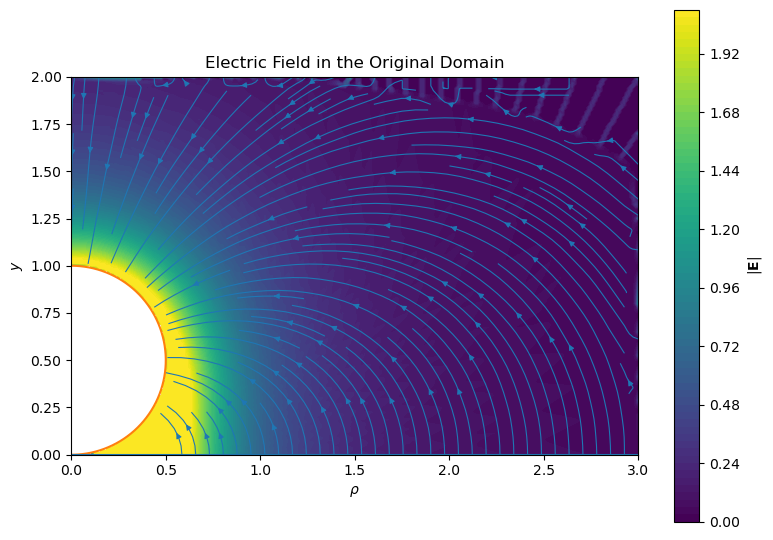

```
Figure saved to: output-sphere-conducting-plane\figures\electric-field.png
```

```python
def plot_electric_field(
    rho_uniform,
    y_uniform,
    rho_uniform_grid,
    y_uniform_grid,
    electric_field_rho,
    electric_field_y,
    electric_field_magnitude,
    figures_dir,
):
    """
    Plot and save the electric field in the original domain

    Inputs:
    -------
    rho_uniform : numpy.ndarray
        One-dimensional radial coordinates

    y_uniform : numpy.ndarray
        One-dimensional vertical coordinates

    rho_uniform_grid : numpy.ndarray
        Two-dimensional radial coordinate grid

    y_uniform_grid : numpy.ndarray
        Two-dimensional vertical coordinate grid

    electric_field_rho : numpy.ndarray
        Radial component of the electric field

    electric_field_y : numpy.ndarray
        Vertical component of the electric field

    electric_field_magnitude : numpy.ndarray
        Magnitude of the electric field

    figures_dir : pathlib.Path
        Directory where the figure is saved

    Outputs:
    --------
    figure_path : pathlib.Path
        Path of the saved PNG figure

    Author:
    -------
    Rodrigo Kang

    """

    finite_field = electric_field_magnitude[
        np.isfinite(electric_field_magnitude)
    ]

    display_limit = np.percentile(
        finite_field,
        97.0,
    )

    displayed_field = np.clip(
        electric_field_magnitude,
        0.0,
        display_limit,
    )

    figure, axis = plt.subplots(
        figsize=(8, 5.5),
    )

    contour = axis.contourf(
        rho_uniform_grid,
        y_uniform_grid,
        displayed_field,
        levels=80,
    )

    colorbar = figure.colorbar(
        contour,
        ax=axis,
    )

    colorbar.set_label(
        r"$|\mathbf{E}|$"
    )

    streamline_step = 5

    stream_rho = rho_uniform[
        ::streamline_step
    ]

    stream_y = y_uniform[
        ::streamline_step
    ]

    stream_field_rho = electric_field_rho[
        ::streamline_step,
        ::streamline_step,
    ]

    stream_field_y = electric_field_y[
        ::streamline_step,
        ::streamline_step,
    ]

    stream_field_rho = np.ma.masked_invalid(
        stream_field_rho
    )

    stream_field_y = np.ma.masked_invalid(
        stream_field_y
    )

    axis.streamplot(
        stream_rho,
        stream_y,
        stream_field_rho,
        stream_field_y,
        density=1.4,
        linewidth=0.8,
        arrowsize=0.8,
    )

    sphere_angle = np.linspace(
        0.0,
        np.pi,
        400,
    )

    sphere_rho = (
        0.5
        * np.sin(sphere_angle)
    )

    sphere_y = (
        0.5
        + 0.5
        * np.cos(sphere_angle)
    )

    axis.plot(
        sphere_rho,
        sphere_y,
        linewidth=1.5,
    )

    axis.axhline(
        y=0.0,
        linewidth=1.5,
    )

    axis.set_xlabel(
        r"$\rho$"
    )

    axis.set_ylabel(
        r"$y$"
    )

    axis.set_title(
        "Electric Field in the Original Domain"
    )

    axis.set_xlim(
        rho_uniform.min(),
        rho_uniform.max(),
    )

    axis.set_ylim(
        y_uniform.min(),
        y_uniform.max(),
    )

    axis.set_aspect(
        "equal",
        adjustable="box",
    )

    figure.tight_layout()

    figure_path = (
        figures_dir
        / "electric-field.png"
    )

    figure.savefig(
        figure_path,
        dpi=300,
        bbox_inches="tight",
    )

    plt.show()

    return figure_path


plt.close("all")


electric_field_figure_path = (
    plot_electric_field(
        rho_uniform=rho_uniform,
        y_uniform=y_uniform,
        rho_uniform_grid=rho_uniform_grid,
        y_uniform_grid=y_uniform_grid,
        electric_field_rho=electric_field_rho,
        electric_field_y=electric_field_y,
        electric_field_magnitude=electric_field_magnitude,
        figures_dir=figures_dir,
    )
)


print(
    f"Figure saved to: "
    f"{electric_field_figure_path}"
)
```

## Surface Charge Density

The surface charge density on a conductor is related to the normal component of the electric field immediately outside its surface.

For a conductor in vacuum,

$$ \sigma = \varepsilon_0 \mathbf{E}\cdot\mathbf{n}, $$

where $\mathbf{n}$ is the outward unit normal vector.

For the spherical conductor,

$$ \rho^2 + \left(y-\frac{1}{2}\right)^2 = \frac{1}{4}, $$

the outward unit normal is

$$ \mathbf{n} = \frac{ \rho\,\mathbf{e}_{\rho} + \left(y-\frac{1}{2}\right)\mathbf{e}_y }{ 1/2 }. $$

The surface is parameterized by

$$ \rho_s(\theta) = \frac{1}{2}\sin\theta, $$

$$ y_s(\theta) = \frac{1}{2} + \frac{1}{2}\cos\theta, $$

with $0\leq\theta\leq\pi$.

The electric field is evaluated slightly outside the conductor to avoid interpolating across the discontinuity between the conducting interior and the exterior domain.

```python
from scipy.interpolate import RegularGridInterpolator


def compute_sphere_charge_density(
    rho_uniform,
    y_uniform,
    electric_field_rho,
    electric_field_y,
    sphere_radius=0.5,
    sphere_center_y=0.5,
    evaluation_offset=0.01,
    n_surface_points=300,
    vacuum_permittivity=1.0,
):
    """
    Compute the surface charge density on the spherical conductor

    Inputs:
    -------
    rho_uniform : numpy.ndarray
        One-dimensional radial coordinates

    y_uniform : numpy.ndarray
        One-dimensional vertical coordinates

    electric_field_rho : numpy.ndarray
        Radial component of the electric field

    electric_field_y : numpy.ndarray
        Vertical component of the electric field

    sphere_radius : float, optional
        Radius of the spherical conductor

    sphere_center_y : float, optional
        Vertical coordinate of the sphere center

    evaluation_offset : float, optional
        Distance outside the conductor used to evaluate the electric field

    n_surface_points : int, optional
        Number of points used to parameterize the spherical surface

    vacuum_permittivity : float, optional
        Permittivity used to scale the surface charge density

    Outputs:
    --------
    sphere_angle : numpy.ndarray
        Angular coordinates along the spherical surface

    surface_rho : numpy.ndarray
        Radial coordinates on the spherical surface

    surface_y : numpy.ndarray
        Vertical coordinates on the spherical surface

    surface_charge_density : numpy.ndarray
        Surface charge density evaluated along the sphere

    Author:
    -------
    Rodrigo Kang

    """

    field_rho_interpolator = RegularGridInterpolator(
        (y_uniform, rho_uniform),
        electric_field_rho,
        bounds_error=False,
        fill_value=np.nan,
    )

    field_y_interpolator = RegularGridInterpolator(
        (y_uniform, rho_uniform),
        electric_field_y,
        bounds_error=False,
        fill_value=np.nan,
    )

    sphere_angle = np.linspace(
        0.0,
        np.pi,
        n_surface_points,
    )

    normal_rho = np.sin(
        sphere_angle
    )

    normal_y = np.cos(
        sphere_angle
    )

    surface_rho = (
        sphere_radius
        * normal_rho
    )

    surface_y = (
        sphere_center_y
        + sphere_radius
        * normal_y
    )

    evaluation_radius = (
        sphere_radius
        + evaluation_offset
    )

    evaluation_rho = (
        evaluation_radius
        * normal_rho
    )

    evaluation_y = (
        sphere_center_y
        + evaluation_radius
        * normal_y
    )

    evaluation_points = np.column_stack(
        (
            evaluation_y,
            evaluation_rho,
        )
    )

    field_rho_surface = (
        field_rho_interpolator(
            evaluation_points
        )
    )

    field_y_surface = (
        field_y_interpolator(
            evaluation_points
        )
    )

    normal_field = (
        field_rho_surface
        * normal_rho
        + field_y_surface
        * normal_y
    )

    surface_charge_density = (
        vacuum_permittivity
        * normal_field
    )

    return (
        sphere_angle,
        surface_rho,
        surface_y,
        surface_charge_density,
    )


(
    sphere_angle,
    surface_rho,
    surface_y,
    surface_charge_density,
) = compute_sphere_charge_density(
    rho_uniform=rho_uniform,
    y_uniform=y_uniform,
    electric_field_rho=electric_field_rho,
    electric_field_y=electric_field_y,
    sphere_radius=0.5,
    sphere_center_y=0.5,
    evaluation_offset=2.0 * max(
        rho_uniform[1] - rho_uniform[0],
        y_uniform[1] - y_uniform[0],
    ),
    vacuum_permittivity=1.0,
)


print(
    f"Maximum finite surface charge density: "
    f"{np.nanmax(surface_charge_density):.6f}"
)

print(
    f"Minimum finite surface charge density: "
    f"{np.nanmin(surface_charge_density):.6f}"
)
```

```
Maximum finite surface charge density: -2.189106
Minimum finite surface charge density: -36.132481
```

### Charge Distribution Along the Sphere

The surface charge density is plotted as a function of the polar angle $\theta$.

The upper point of the sphere corresponds to $\theta=0$, while the tangency point with the plane corresponds to $\theta=\pi$.

Because the geometry becomes singular at the tangency point, the numerical estimate is expected to become increasingly sensitive as $\theta$ approaches $\pi$. Values extremely close to this point are therefore omitted from the plot.

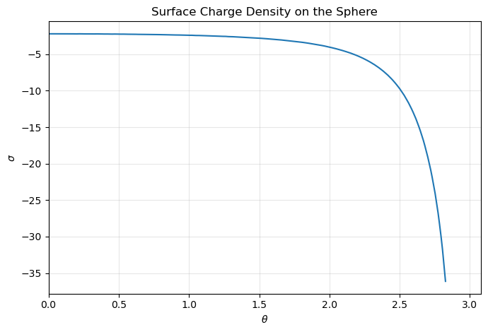

```
Figure saved to: output-sphere-conducting-plane\figures\sphere-charge.png
```

```python
def plot_sphere_charge_density(
    sphere_angle,
    surface_charge_density,
    figures_dir,
    excluded_angle_fraction=0.02,
):
    """
    Plot and save the surface charge density along the spherical conductor

    Inputs:
    -------
    sphere_angle : numpy.ndarray
        Angular coordinates along the spherical surface

    surface_charge_density : numpy.ndarray
        Surface charge density evaluated along the sphere

    figures_dir : pathlib.Path
        Directory where the figure is saved

    excluded_angle_fraction : float, optional
        Fraction of the angular range excluded near the tangency point

    Outputs:
    --------
    figure_path : pathlib.Path
        Path of the saved PNG figure

    Author:
    -------
    Rodrigo Kang

    """

    maximum_angle = (
        np.pi
        * (1.0 - excluded_angle_fraction)
    )

    valid_mask = (
        np.isfinite(surface_charge_density)
        & (sphere_angle <= maximum_angle)
    )

    figure, axis = plt.subplots(
        figsize=(7, 4.8),
    )

    axis.plot(
        sphere_angle[valid_mask],
        surface_charge_density[valid_mask],
    )

    axis.set_xlabel(
        r"$\theta$"
    )

    axis.set_ylabel(
        r"$\sigma$"
    )

    axis.set_title(
        "Surface Charge Density on the Sphere"
    )

    axis.set_xlim(
        0.0,
        maximum_angle,
    )

    axis.grid(
        True,
        alpha=0.3,
    )

    figure.tight_layout()

    figure_path = (
        figures_dir
        / "sphere-charge.png"
    )

    figure.savefig(
        figure_path,
        dpi=300,
        bbox_inches="tight",
    )

    plt.show()

    return figure_path


sphere_charge_figure_path = (
    plot_sphere_charge_density(
        sphere_angle=sphere_angle,
        surface_charge_density=surface_charge_density,
        figures_dir=figures_dir,
    )
)


print(
    f"Figure saved to: "
    f"{sphere_charge_figure_path}"
)
```

## Total Charge on the Sphere

Under axisymmetry, the surface element of the sphere is

$$ dA = 2\pi R^2\sin\theta\,d\theta. $$

The total charge on the spherical conductor can therefore be approximated by

$$ Q = 2\pi R^2 \int_0^\pi \sigma(\theta) \sin\theta \,d\theta. $$

Since the numerical field becomes unreliable extremely close to the tangency point, the integral is evaluated only over the finite portion of the surface for which the interpolated charge density is available. The resulting value should therefore be interpreted as a truncated numerical estimate rather than an exact total charge.

```python
def estimate_total_sphere_charge(
    sphere_angle,
    surface_charge_density,
    sphere_radius=0.5,
    excluded_angle_fraction=0.02,
):
    """
    Estimate the total charge on the spherical conductor

    Inputs:
    -------
    sphere_angle : numpy.ndarray
        Angular coordinates along the spherical surface

    surface_charge_density : numpy.ndarray
        Surface charge density evaluated along the sphere

    sphere_radius : float, optional
        Radius of the spherical conductor

    excluded_angle_fraction : float, optional
        Fraction of the angular range excluded near the tangency point

    Outputs:
    --------
    total_charge : float
        Truncated numerical estimate of the total charge

    Author:
    -------
    Rodrigo Kang

    """

    maximum_angle = (
        np.pi
        * (1.0 - excluded_angle_fraction)
    )

    valid_mask = (
        np.isfinite(surface_charge_density)
        & (sphere_angle <= maximum_angle)
    )

    valid_angle = sphere_angle[
        valid_mask
    ]

    valid_charge_density = (
        surface_charge_density[
            valid_mask
        ]
    )

    charge_integrand = (
        valid_charge_density
        * np.sin(valid_angle)
    )

    total_charge = (
        2.0
        * np.pi
        * sphere_radius**2
        * np.trapezoid(
            charge_integrand,
            valid_angle,
        )
    )

    return total_charge


total_sphere_charge = (
    estimate_total_sphere_charge(
        sphere_angle=sphere_angle,
        surface_charge_density=surface_charge_density,
        sphere_radius=0.5,
    )
)


print(
    f"Truncated total charge on the sphere: "
    f"{total_sphere_charge:.6f}"
)
```

```
Truncated total charge on the sphere: -13.611814
```

## Numerical Summary

The main numerical diagnostics are collected in a compact summary table.

The reported quantities include:

- the maximum and mean absolute residual of the transformed finite-difference solution;
- the relative differences between successive grid refinements;
- the maximum boundary-condition errors;
- the minimum and maximum estimated surface charge density;
- the truncated estimate of the total charge on the sphere.

These values provide a concise record of the numerical behaviour of the implementation. They should be interpreted together with the residual map, convergence plot, and field visualizations.

```python
import pandas as pd


def build_numerical_summary(
    maximum_residual,
    mean_residual,
    grid_sizes,
    grid_differences,
    grid_maximum_differences,
    grid_solve_times,
    boundary_errors,
    surface_charge_density,
    total_sphere_charge,
):
    """
    Build a table containing the main numerical diagnostics

    Inputs:
    -------
    maximum_residual : float
        Maximum absolute residual of the transformed solution

    mean_residual : float
        Mean absolute residual of the transformed solution

    grid_sizes : list of tuple
        Grid dimensions used in the convergence study

    grid_differences : list of float
        Relative L2 differences between successive grid solutions

    grid_maximum_differences : list of float
        Maximum absolute differences between successive grid solutions

    grid_solve_times : list of float
        Linear-system workflow time for each grid

    boundary_errors : dict
        Maximum errors along the prescribed Dirichlet boundaries

    surface_charge_density : numpy.ndarray
        Estimated surface charge density along the sphere

    total_sphere_charge : float
        Truncated estimate of the total charge on the sphere

    Outputs:
    --------
    numerical_summary : pandas.DataFrame
        Table containing the principal numerical diagnostics

    Author:
    -------
    Rodrigo Kang

    """

    finite_charge_density = surface_charge_density[
        np.isfinite(surface_charge_density)
    ]

    summary_rows = [
        {
            "quantity": "Maximum absolute residual",
            "value": maximum_residual,
        },
        {
            "quantity": "Mean absolute residual",
            "value": mean_residual,
        },
        {
            "quantity": "Lower boundary error",
            "value": boundary_errors[
                "lower_boundary"
            ],
        },
        {
            "quantity": "Upper boundary error",
            "value": boundary_errors[
                "upper_boundary"
            ],
        },
        {
            "quantity": "Outer boundary error",
            "value": boundary_errors[
                "outer_boundary"
            ],
        },
        {
            "quantity": "Minimum sphere charge density",
            "value": np.min(
                finite_charge_density
            ),
        },
        {
            "quantity": "Maximum sphere charge density",
            "value": np.max(
                finite_charge_density
            ),
        },
        {
            "quantity": "Truncated total sphere charge",
            "value": total_sphere_charge,
        },
    ]

    for grid_index, relative_difference in enumerate(
        grid_differences
    ):
        coarse_size = grid_sizes[
            grid_index
        ]

        fine_size = grid_sizes[
            grid_index + 1
        ]

        summary_rows.append(
            {
                "quantity": (
                    "Grid difference "
                    f"{coarse_size[0]}x{coarse_size[1]} "
                    "to "
                    f"{fine_size[0]}x{fine_size[1]}"
                ),
                "value": relative_difference,
            }
        )

        summary_rows.append(
            {
                "quantity": (
                    "Maximum grid difference "
                    f"{coarse_size[0]}x{coarse_size[1]} "
                    "to "
                    f"{fine_size[0]}x{fine_size[1]}"
                ),
                "value": grid_maximum_differences[grid_index],
            }
        )

    for grid_size, solve_seconds in zip(
        grid_sizes,
        grid_solve_times,
    ):
        summary_rows.append(
            {
                "quantity": (
                    f"Solve time {grid_size[0]}x{grid_size[1]} (s)"
                ),
                "value": solve_seconds,
            }
        )

    numerical_summary = pd.DataFrame(
        summary_rows
    )

    return numerical_summary


numerical_summary = build_numerical_summary(
    maximum_residual=maximum_residual,
    mean_residual=mean_residual,
    grid_sizes=grid_sizes,
    grid_differences=grid_differences,
    grid_maximum_differences=grid_maximum_differences,
    grid_solve_times=grid_solve_times,
    boundary_errors=boundary_errors,
    surface_charge_density=surface_charge_density,
    total_sphere_charge=total_sphere_charge,
)


numerical_summary
```

|  | quantity | value |
| --- | --- | --- |
| 0 | Maximum absolute residual | 5.547918e-11 |
| 1 | Mean absolute residual | 4.747375e-13 |
| 2 | Lower boundary error | 0.000000e+00 |
| 3 | Upper boundary error | 0.000000e+00 |
| 4 | Outer boundary error | 0.000000e+00 |
| 5 | Minimum sphere charge density | -3.613248e+01 |
| 6 | Maximum sphere charge density | -2.189106e+00 |
| 7 | Truncated total sphere charge | -1.361181e+01 |
| 8 | Grid difference 41x21 to 81x41 | 3.115535e-02 |
| 9 | Maximum grid difference 41x21 to 81x41 | 9.956764e-02 |
| 10 | Grid difference 81x41 to 161x81 | 1.892064e-02 |
| 11 | Maximum grid difference 81x41 to 161x81 | 8.863640e-02 |
| 12 | Grid difference 161x81 to 321x161 | 1.028523e-02 |
| 13 | Maximum grid difference 161x81 to 321x161 | 6.219708e-02 |
| 14 | Solve time 41x21 (s) | 9.711300e-03 |
| 15 | Solve time 81x41 (s) | 3.685200e-02 |
| 16 | Solve time 161x81 (s) | 1.485035e-01 |
| 17 | Solve time 321x161 (s) | 6.546837e-01 |

## Exporting Numerical Results

The principal numerical outputs are exported as CSV files so that they can be inspected independently of the notebook and reused in the corresponding Quarto chapter.

The exported files contain:

- the numerical summary;
- the transformed-domain potential;
- the interpolated original-domain potential;
- the electric-field components and magnitude;
- the estimated surface charge density along the sphere.

```python
results_dir = Path(
    "output-sphere-conducting-plane/results"
)

results_dir.mkdir(
    parents=True,
    exist_ok=True,
)
```

```python
def export_numerical_results(
    results_dir,
    numerical_summary,
    grid_sizes,
    grid_differences,
    grid_maximum_differences,
    grid_solve_times,
    rho,
    y,
    transformed_potential,
    rho_uniform_grid,
    y_uniform_grid,
    potential_uniform,
    electric_field_rho,
    electric_field_y,
    electric_field_magnitude,
    sphere_angle,
    surface_rho,
    surface_y,
    surface_charge_density,
):
    """
    Export the principal numerical results as CSV files

    Inputs:
    -------
    results_dir : pathlib.Path
        Directory where the CSV files are saved

    numerical_summary : pandas.DataFrame
        Table containing the principal numerical diagnostics

    grid_sizes : list of tuple
        Grid dimensions used in the convergence study

    grid_differences : list of float
        Relative L2 differences between successive grid solutions

    grid_maximum_differences : list of float
        Maximum absolute differences between successive solutions

    grid_solve_times : list of float
        Solution time for each convergence grid

    rho : numpy.ndarray
        Radial coordinates in the transformed domain

    y : numpy.ndarray
        Vertical coordinates in the transformed domain

    transformed_potential : numpy.ndarray
        Potential evaluated in the transformed domain

    rho_uniform_grid : numpy.ndarray
        Uniform radial coordinate grid in the original domain

    y_uniform_grid : numpy.ndarray
        Uniform vertical coordinate grid in the original domain

    potential_uniform : numpy.ndarray
        Interpolated potential in the original domain

    electric_field_rho : numpy.ndarray
        Radial component of the electric field

    electric_field_y : numpy.ndarray
        Vertical component of the electric field

    electric_field_magnitude : numpy.ndarray
        Magnitude of the electric field

    sphere_angle : numpy.ndarray
        Angular coordinates along the spherical conductor

    surface_rho : numpy.ndarray
        Radial coordinates along the sphere

    surface_y : numpy.ndarray
        Vertical coordinates along the sphere

    surface_charge_density : numpy.ndarray
        Estimated surface charge density along the sphere

    Outputs:
    --------
    exported_files : dict
        Paths of the exported CSV files

    Author:
    -------
    Rodrigo Kang

    """

    numerical_summary_path = (
        results_dir
        / "numerical-summary.csv"
    )

    numerical_summary.to_csv(
        numerical_summary_path,
        index=False,
    )


    convergence_rows = []

    for grid_index, grid_size in enumerate(grid_sizes):
        convergence_rows.append(
            {
                "n_rho": grid_size[0],
                "n_y": grid_size[1],
                "delta_rho": rho_max / (grid_size[0] - 1),
                "delta_y": y_max / (grid_size[1] - 1),
                "solve_seconds": grid_solve_times[grid_index],
                "relative_l2_to_next": (
                    grid_differences[grid_index]
                    if grid_index < len(grid_differences)
                    else np.nan
                ),
                "maximum_absolute_to_next": (
                    grid_maximum_differences[grid_index]
                    if grid_index < len(grid_maximum_differences)
                    else np.nan
                ),
            }
        )

    grid_convergence_path = (
        results_dir / "grid-convergence.csv"
    )

    pd.DataFrame(convergence_rows).to_csv(
        grid_convergence_path,
        index=False,
    )

    transformed_rho_grid, transformed_y_grid = (
        np.meshgrid(
            rho,
            y,
        )
    )

    transformed_data = pd.DataFrame(
        {
            "rho_prime": (
                transformed_rho_grid.ravel()
            ),
            "y_prime": (
                transformed_y_grid.ravel()
            ),
            "grid_convergence": (
            grid_convergence_path
        ),
        "transformed_potential": (
                transformed_potential.ravel()
            ),
        }
    )

    transformed_potential_path = (
        results_dir
        / "transformed-potential.csv"
    )

    transformed_data.to_csv(
        transformed_potential_path,
        index=False,
    )

    original_data = pd.DataFrame(
        {
            "rho": (
                rho_uniform_grid.ravel()
            ),
            "y": (
                y_uniform_grid.ravel()
            ),
            "potential": (
                potential_uniform.ravel()
            ),
            "electric_field_rho": (
                electric_field_rho.ravel()
            ),
            "electric_field_y": (
                electric_field_y.ravel()
            ),
            "electric_field_magnitude": (
                electric_field_magnitude.ravel()
            ),
        }
    )

    original_potential_path = (
        results_dir
        / "original-field.csv"
    )

    original_data.to_csv(
        original_potential_path,
        index=False,
    )

    surface_charge_data = pd.DataFrame(
        {
            "theta": sphere_angle,
            "rho": surface_rho,
            "y": surface_y,
            "surface_charge_density": (
                surface_charge_density
            ),
        }
    )

    surface_charge_path = (
        results_dir
        / "sphere-charge.csv"
    )

    surface_charge_data.to_csv(
        surface_charge_path,
        index=False,
    )

    exported_files = {
        "numerical_summary": (
            numerical_summary_path
        ),
        "grid_convergence": (
            grid_convergence_path
        ),
        "transformed_potential": (
            transformed_potential_path
        ),
        "original_field": (
            original_potential_path
        ),
        "sphere_charge": (
            surface_charge_path
        ),
    }

    return exported_files


exported_files = export_numerical_results(
    results_dir=results_dir,
    numerical_summary=numerical_summary,
    grid_sizes=grid_sizes,
    grid_differences=grid_differences,
    grid_maximum_differences=grid_maximum_differences,
    grid_solve_times=grid_solve_times,
    rho=rho,
    y=y,
    transformed_potential=transformed_potential,
    rho_uniform_grid=rho_uniform_grid,
    y_uniform_grid=y_uniform_grid,
    potential_uniform=potential_uniform,
    electric_field_rho=electric_field_rho,
    electric_field_y=electric_field_y,
    electric_field_magnitude=electric_field_magnitude,
    sphere_angle=sphere_angle,
    surface_rho=surface_rho,
    surface_y=surface_y,
    surface_charge_density=surface_charge_density,
)


for result_name, result_path in exported_files.items():
    print(
        f"{result_name}: "
        f"{result_path}"
    )
```

```
numerical_summary: output-sphere-conducting-plane\results\numerical-summary.csv
grid_convergence: output-sphere-conducting-plane\results\grid-convergence.csv
transformed_potential: output-sphere-conducting-plane\results\transformed-potential.csv
original_field: output-sphere-conducting-plane\results\original-field.csv
sphere_charge: output-sphere-conducting-plane\results\sphere-charge.csv
```

## Implementation Remarks

The numerical implementation illustrates the complete workflow from the conformally transformed boundary-value problem to the reconstruction of the potential and electric field in the original geometry.

Several aspects require care when interpreting the results.

First, the transformed lower boundary is singular at $\rho'=0$. The singular value is regularized using the first non-zero radial grid spacing. Consequently, numerical quantities close to the transformed origin depend on the selected grid resolution.

Second, the radial domain is truncated at $\rho'=\rho'_{\max}$. The imposed zero potential at this artificial boundary approximates the decay of the transformed solution at large radial distance. The value of $\rho'_{\max}$ should therefore be sufficiently large for the region of interest to remain insensitive to this truncation.

Third, the inverse transformation maps the regular transformed grid onto a non-uniform set of points in the original domain. The reconstructed potential and electric field consequently include interpolation error in addition to the finite-difference discretization error.

Finally, the electric field and surface charge density are obtained by differentiating an interpolated numerical potential. These derived quantities are more sensitive than the potential itself, particularly near the point where the sphere touches the plane. For this reason, the field and charge-density results should be interpreted primarily as numerical descriptions of the spatial behaviour rather than exact estimates at the singular contact point.